# SYS 6018 Semester Project Part 1

Camille Leonard

### **Project Introduction**

The objective of this project is to create predictive models to accurately and quickly identify the locations of people in need of aid from data collected by Rochester Institute of Technology in the wake of the 2010 earthquake in Haiti.

In part one of this project, logistic regression, LDA, QDA, and KNN methods will be used to create models.

```r
df <- tibble(read.csv("HaitiPixels.csv")) #read in df
anyNA(df) #check for NA values
```

```
[1] FALSE
```

```r
summary(df) #quick look at data
```

```
    Class                Red          Green            Blue
 Length:63241       Min.   : 48   Min.   : 48.0   Min.   : 44.0
 Class :character   1st Qu.: 80   1st Qu.: 78.0   1st Qu.: 63.0
 Mode  :character   Median :163   Median :148.0   Median :123.0
                    Mean   :163   Mean   :153.7   Mean   :125.1
                    3rd Qu.:255   3rd Qu.:226.0   3rd Qu.:181.0
                    Max.   :255   Max.   :255.0   Max.   :255.0
```

```
Extra arguments: "lower.panel" are being ignored.  If these are meant to be aesthetics, submit them using the 'mapping' variable within ggpairs with ggplot2::aes or ggplot2::aes_string.
```

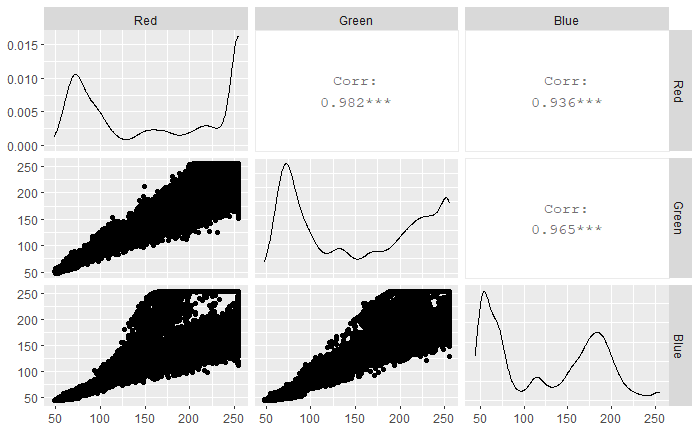

```r
ggpairs(df[,2:4], lower.panel = NULL) #view scatter and correlations
```

```r
df$Class <- factor(df$Class) #make Class a factor variable.
attach(df) #attach df variables
```

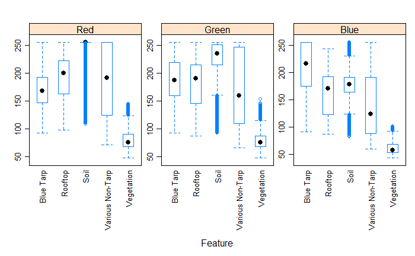

```r
#take a look at the distribution of classes and RBG values
featurePlot(x = df[,2:4],
            y = df$Class,
            plot = "box",
            layout = c(3,1),
            scales = list(y = list(relation = "free"),
                          x = list(rot = 90)))
```

```r
df <- cbind(mutate(df, "Blue_Tarp_or_Not"=ifelse(Class != "Blue Tarp", 0, 1))) #add binary column indicating whether the Class variable is "Blue Tarp" or not
attach(df)
Blue_Tarp_or_Not <- as.factor(Blue_Tarp_or_Not) #ensure new column is a factor
df
```

| Class | Red | Green | Blue | Blue_Tarp_or_Not |
| --- | --- | --- | --- | --- |
| Vegetation | 64 | 67 | 50 | 0 |
| Vegetation | 64 | 67 | 50 | 0 |
| Vegetation | 64 | 66 | 49 | 0 |
| Vegetation | 75 | 82 | 53 | 0 |
| Vegetation | 74 | 82 | 54 | 0 |
| Vegetation | 72 | 76 | 52 | 0 |
| Vegetation | 71 | 72 | 51 | 0 |
| Vegetation | 69 | 70 | 49 | 0 |
| Vegetation | 68 | 70 | 49 | 0 |
| Vegetation | 67 | 70 | 50 | 0 |

[output cut: 990 more lines]

```r
tail(df)
```

|  | Class | Red | Green | Blue | Blue_Tarp_or_Not |
| --- | --- | --- | --- | --- | --- |
| 63236 | Blue Tarp | 136 | 145 | 150 | 1 |
| 63237 | Blue Tarp | 138 | 146 | 150 | 1 |
| 63238 | Blue Tarp | 134 | 141 | 152 | 1 |
| 63239 | Blue Tarp | 136 | 143 | 151 | 1 |
| 63240 | Blue Tarp | 132 | 139 | 149 | 1 |
| 63241 | Blue Tarp | 133 | 141 | 153 | 1 |

```r
NA
```

```r
#create training and final hold out set (called test)
set.seed(4)
trainIndex <- createDataPartition(Class, p=0.8,
                                  list=FALSE,
                                  times=1)

blueTarpTrain <- df[trainIndex,]
blueTarpTrain$Blue_Tarp_or_Not <- as.factor(blueTarpTrain$Blue_Tarp_or_Not)
blueTarpTrain <- blueTarpTrain[,-1] #remove Class column
blueTarpTest <- df[-trainIndex,]
blueTarpTest$Blue_Tarp_or_Not <- as.factor(blueTarpTest$Blue_Tarp_or_Not)
blueTarpTest <- blueTarpTest[,-1] #remove Class column
```

## Logistic Regression

```r
fitControl <- trainControl(method = "repeatedcv",
                           number = 10,
                           repeats = 10) #set fitControl parameters such that 10 folds and 10 repeats are done

set.seed(4)
glm.fit <- caret::train(Blue_Tarp_or_Not~Red+Green+Blue,
                    data = blueTarpTrain,
                    method="glm",
                    family="binomial",
                    trControl= fitControl)

glm.fit
```

```
Generalized Linear Model

50595 samples
    3 predictor
    2 classes: '0', '1'

No pre-processing
Resampling: Cross-Validated (10 fold, repeated 10 times)
Summary of sample sizes: 45535, 45536, 45535, 45535, 45535, 45536, ...
Resampling results:

  Accuracy   Kappa
  0.9951062  0.9174991
```

```r
summary(glm.fit)
```

```
Call:
NULL

Deviance Residuals:
    Min       1Q   Median       3Q      Max
-3.3526  -0.0225  -0.0018   0.0000   3.7324

Coefficients:
            Estimate Std. Error z value Pr(>|z|)
(Intercept)  0.05955    0.20122   0.296    0.767
Red         -0.24556    0.01390 -17.667   <2e-16 ***
Green       -0.21744    0.01523 -14.278   <2e-16 ***
Blue         0.45760    0.01652  27.706   <2e-16 ***
---
Signif. codes:  0 ‘***’ 0.001 ‘**’ 0.01 ‘*’ 0.05 ‘.’ 0.1 ‘ ’ 1

(Dispersion parameter for binomial family taken to be 1)

    Null deviance: 14324.2  on 50594  degrees of freedom
Residual deviance:  1470.4  on 50591  degrees of freedom
AIC: 1478.4

Number of Fisher Scoring iterations: 12
```

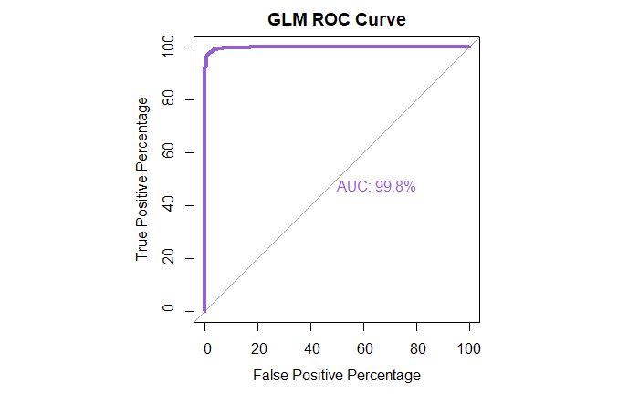

```r
glm.prob <- predict(glm.fit, newdata=blueTarpTrain, type = "prob") #returns df with col 0 (prob not blue tarp) and 1 (prob blue tarp)
par(pty="s")
glm_roc <- roc(blueTarpTrain$Blue_Tarp_or_Not, glm.prob[,2], plot=TRUE, legacy.axes=TRUE, percent=TRUE, xlab="False Positive Percentage", ylab="True Positive Percentage", col="#965fd4", lwd=4, print.auc=TRUE, main="GLM ROC Curve")
```

```r
roc.info_glm <- roc(blueTarpTrain$Blue_Tarp_or_Not, glm.prob[,2], legacy.axes=TRUE)
roc.glm.df <- data.frame(tpp=roc.info_glm$sensitivities*100, fpp=(1-roc.info_glm$specificities)*100, thresholds=roc.info_glm$thresholds)
roc.glm.df[roc.glm.df>98.5 & roc.glm.df < 99,]
```

|  | tpp | fpp | thresholds |
| --- | --- | --- | --- |
| 18764 | 98.94932 | 3.307675 | 0.01438275 |
| 18765 | 98.94932 | 3.303591 | 0.01442949 |
| 18766 | 98.94932 | 3.301550 | 0.01447613 |
| 18767 | 98.94932 | 3.297466 | 0.01452301 |
| 18768 | 98.94932 | 3.295424 | 0.01456994 |
| 18769 | 98.94932 | 3.289299 | 0.01458665 |
| 18770 | 98.94932 | 3.287257 | 0.01462548 |
| 18771 | 98.94932 | 3.283174 | 0.01466436 |
| 18772 | 98.94932 | 3.279090 | 0.01467797 |
| 18773 | 98.88752 | 3.279090 | 0.01468623 |

[output cut: 157 more lines]

```r
glm.pred_50 <- ifelse(glm.prob[,2]>0.5,1,0)
cm.glm_50 <- confusionMatrix(factor(glm.pred_50), factor(blueTarpTrain$Blue_Tarp_or_Not), positive = '1')
"Threshold: 0.5"
```

```
[1] "Threshold: 0.5"
```

```r
cm.glm_50
```

```
Confusion Matrix and Statistics

          Reference
Prediction     0     1
         0 48922   192
         1    55  1426

               Accuracy : 0.9951
                 95% CI : (0.9945, 0.9957)
    No Information Rate : 0.968
    P-Value [Acc > NIR] : < 2.2e-16

                  Kappa : 0.9178

 Mcnemar's Test P-Value : < 2.2e-16

            Sensitivity : 0.88133
            Specificity : 0.99888
         Pos Pred Value : 0.96286
         Neg Pred Value : 0.99609
             Prevalence : 0.03198
         Detection Rate : 0.02818
   Detection Prevalence : 0.02927
      Balanced Accuracy : 0.94011

       'Positive' Class : 1
```

```r
glm.pred_15 <- ifelse(glm.prob[,2]>0.15,1,0)
cm.glm_15 <- confusionMatrix(factor(glm.pred_15), factor(blueTarpTrain$Blue_Tarp_or_Not), positive = '1')
"Threshold: 0.15"
```

```
[1] "Threshold: 0.15"
```

```r
cm.glm_15
```

```
Confusion Matrix and Statistics

          Reference
Prediction     0     1
         0 48633    87
         1   344  1531

               Accuracy : 0.9915
                 95% CI : (0.9906, 0.9923)
    No Information Rate : 0.968
    P-Value [Acc > NIR] : < 2.2e-16

                  Kappa : 0.8722

 Mcnemar's Test P-Value : < 2.2e-16

            Sensitivity : 0.94623
            Specificity : 0.99298
         Pos Pred Value : 0.81653
         Neg Pred Value : 0.99821
             Prevalence : 0.03198
         Detection Rate : 0.03026
   Detection Prevalence : 0.03706
      Balanced Accuracy : 0.96960

       'Positive' Class : 1
```

## LDA

```r
fitControl <- trainControl(method = "repeatedcv",
                           number = 10,
                           repeats = 10)

set.seed(4)
lda.fit <- caret::train(Blue_Tarp_or_Not~Red+Green+Blue,
                    data = blueTarpTrain,
                    preProcess=c("center","scale"),
                    method="lda",
                    verbose= FALSE,
                    trControl= fitControl)

lda.fit
```

```
Linear Discriminant Analysis

50595 samples
    3 predictor
    2 classes: '0', '1'

Pre-processing: centered (3), scaled (3)
Resampling: Cross-Validated (10 fold, repeated 10 times)
Summary of sample sizes: 45535, 45536, 45535, 45535, 45535, 45536, ...
Resampling results:

  Accuracy   Kappa
  0.9838205  0.7522787
```

```r
#summary(lda.fit)
```

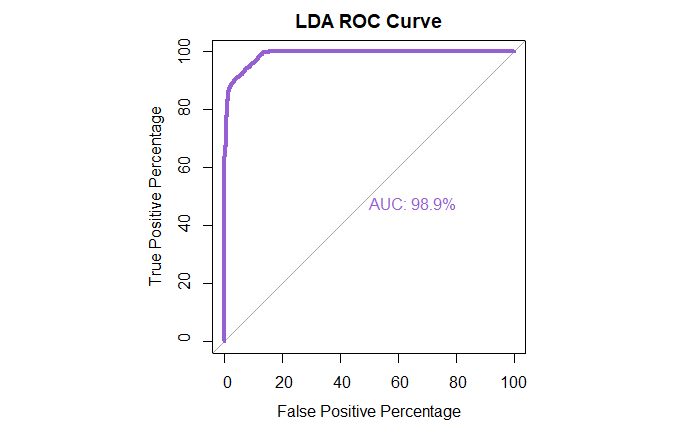

```r
lda.prob <- predict(lda.fit, newdata=blueTarpTrain, type = "prob") #returns df with col 0 (prob not blue tarp) and 1 (prob blue tarp)
par(pty="s")
lda_roc <- roc(blueTarpTrain$Blue_Tarp_or_Not, lda.prob[,2], plot=TRUE, legacy.axes=TRUE, percent=TRUE, xlab="False Positive Percentage", ylab="True Positive Percentage", col="#965fd4", lwd=4, print.auc=TRUE, main="LDA ROC Curve")
```

```r
roc.info_lda <- roc(blueTarpTrain$Blue_Tarp_or_Not, lda.prob[,2], legacy.axes=TRUE)
roc.lda.df <- data.frame(tpp=roc.info_lda$sensitivities*100, fpp=(1-roc.info_lda$specificities)*100, thresholds=roc.info_lda$thresholds)
roc.lda.df[roc.lda.df>91.5 & roc.lda.df < 91.6,]
```

|  | tpp | fpp | thresholds |
| --- | --- | --- | --- |
| 21716 | 91.59456 | 5.157523 | 0.001548619 |
| 21717 | 91.59456 | 5.155481 | 0.001549401 |
| 21718 | 91.59456 | 5.153439 | 0.001550276 |
| 21719 | 91.59456 | 5.151398 | 0.001550931 |
| 21720 | 91.59456 | 5.149356 | 0.001551572 |
| 21721 | 91.59456 | 5.147314 | 0.001552355 |
| 21722 | 91.59456 | 5.145272 | 0.001554016 |
| 21723 | 91.59456 | 5.143230 | 0.001555864 |
| 21724 | 91.59456 | 5.141189 | 0.001557528 |
| 21725 | 91.59456 | 5.139147 | 0.001558550 |

[output cut: 38 more lines]

```r
lda.pred_50 <- ifelse(lda.prob[,2]>0.5,1,0)
cm.lda_50 <- confusionMatrix(factor(lda.pred_50), factor(blueTarpTrain$Blue_Tarp_or_Not), positive = '1')
"Threshold: 0.5"
```

```
[1] "Threshold: 0.5"
```

```r
cm.lda_50
```

```
Confusion Matrix and Statistics

          Reference
Prediction     0     1
         0 48476   318
         1   501  1300

               Accuracy : 0.9838
                 95% CI : (0.9827, 0.9849)
    No Information Rate : 0.968
    P-Value [Acc > NIR] : < 2.2e-16

                  Kappa : 0.7521

 Mcnemar's Test P-Value : 2.023e-10

            Sensitivity : 0.80346
            Specificity : 0.98977
         Pos Pred Value : 0.72182
         Neg Pred Value : 0.99348
             Prevalence : 0.03198
         Detection Rate : 0.02569
   Detection Prevalence : 0.03560
      Balanced Accuracy : 0.89662

       'Positive' Class : 1
```

```r
lda.pred_10 <- ifelse(lda.prob[,2]>0.10,1,0)
cm.lda_10 <- confusionMatrix(factor(lda.pred_10), factor(blueTarpTrain$Blue_Tarp_or_Not), positive = '1')
"Threshold: 0.10"
```

```
[1] "Threshold: 0.10"
```

```r
cm.lda_10
```

```
Confusion Matrix and Statistics

          Reference
Prediction     0     1
         0 48322   247
         1   655  1371

               Accuracy : 0.9822
                 95% CI : (0.981, 0.9833)
    No Information Rate : 0.968
    P-Value [Acc > NIR] : < 2.2e-16

                  Kappa : 0.7433

 Mcnemar's Test P-Value : < 2.2e-16

            Sensitivity : 0.84734
            Specificity : 0.98663
         Pos Pred Value : 0.67670
         Neg Pred Value : 0.99491
             Prevalence : 0.03198
         Detection Rate : 0.02710
   Detection Prevalence : 0.04004
      Balanced Accuracy : 0.91698

       'Positive' Class : 1
```

## QDA

```r
fitControl <- trainControl(method = "repeatedcv",
                           number = 10,
                           repeats = 10)

set.seed(4)
qda.fit <- caret::train(Blue_Tarp_or_Not~Red+Green+Blue,
                    data = blueTarpTrain,
                    preProcess=c("center","scale"),
                    method="qda",
                    verbose= FALSE,
                    trControl= fitControl)

qda.fit
```

```
Quadratic Discriminant Analysis

50595 samples
    3 predictor
    2 classes: '0', '1'

Pre-processing: centered (3), scaled (3)
Resampling: Cross-Validated (10 fold, repeated 10 times)
Summary of sample sizes: 45535, 45536, 45535, 45535, 45535, 45536, ...
Resampling results:

  Accuracy   Kappa
  0.9946279  0.9062307
```

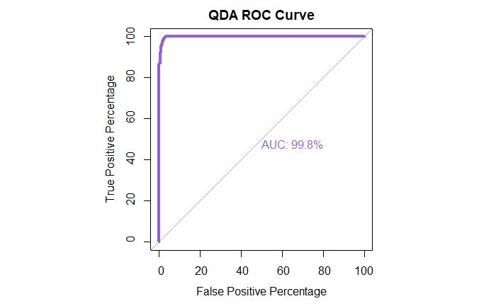

```r
qda.prob <- predict(qda.fit, newdata=blueTarpTrain, type = "prob") #returns df with col 0 (prob not blue tarp) and 1 (prob blue tarp)
par(pty="s")
qda_roc <- roc(blueTarpTrain$Blue_Tarp_or_Not, qda.prob[,2], plot=TRUE, legacy.axes=TRUE, percent=TRUE, xlab="False Positive Percentage", ylab="True Positive Percentage", col="#965fd4", lwd=4, print.auc=TRUE, main="QDA ROC Curve")
```

```r
roc.info_qda <- roc(blueTarpTrain$Blue_Tarp_or_Not, qda.prob[,2], legacy.axes=TRUE)
roc.qda.df <- data.frame(tpp=roc.info_qda$sensitivities*100, fpp=(1-roc.info_qda$specificities)*100, thresholds=roc.info_qda$thresholds)
roc.qda.df[roc.qda.df>98 & roc.qda.df < 99,]
```

|  | tpp | fpp | thresholds |
| --- | --- | --- | --- |
| 22239 | 98.94932 | 2.368459 | 0.02078736 |
| 22240 | 98.94932 | 2.366417 | 0.02083603 |
| 22241 | 98.94932 | 2.364375 | 0.02085548 |
| 22242 | 98.94932 | 2.360292 | 0.02086075 |
| 22243 | 98.94932 | 2.358250 | 0.02087175 |
| 22244 | 98.94932 | 2.356208 | 0.02090847 |
| 22245 | 98.94932 | 2.354166 | 0.02094353 |
| 22246 | 98.94932 | 2.352124 | 0.02095783 |
| 22247 | 98.94932 | 2.341916 | 0.02102842 |
| 22248 | 98.94932 | 2.339874 | 0.02111149 |

[output cut: 524 more lines]

```r
qda.pred_50 <- ifelse(qda.prob[,2]>0.5,1,0)
cm.qda_50 <- confusionMatrix(factor(qda.pred_50), factor(blueTarpTrain$Blue_Tarp_or_Not), positive = '1')
"Threshold: 0.5"
```

```
[1] "Threshold: 0.5"
```

```r
cm.qda_50
```

```
Confusion Matrix and Statistics

          Reference
Prediction     0     1
         0 48963   257
         1    14  1361

               Accuracy : 0.9946
                 95% CI : (0.994, 0.9953)
    No Information Rate : 0.968
    P-Value [Acc > NIR] : < 2.2e-16

                  Kappa : 0.9067

 Mcnemar's Test P-Value : < 2.2e-16

            Sensitivity : 0.84116
            Specificity : 0.99971
         Pos Pred Value : 0.98982
         Neg Pred Value : 0.99478
             Prevalence : 0.03198
         Detection Rate : 0.02690
   Detection Prevalence : 0.02718
      Balanced Accuracy : 0.92044

       'Positive' Class : 1
```

```r
qda.pred_10 <- ifelse(qda.prob[,2]>0.10,1,0)
cm.qda_10 <- confusionMatrix(factor(qda.pred_10), factor(blueTarpTrain$Blue_Tarp_or_Not), positive = '1')
"Threshold: 0.10"
```

```
[1] "Threshold: 0.10"
```

```r
cm.qda_10
```

```
Confusion Matrix and Statistics

          Reference
Prediction     0     1
         0 48621   162
         1   356  1456

               Accuracy : 0.9898
                 95% CI : (0.9888, 0.9906)
    No Information Rate : 0.968
    P-Value [Acc > NIR] : < 2.2e-16

                  Kappa : 0.8437

 Mcnemar's Test P-Value : < 2.2e-16

            Sensitivity : 0.89988
            Specificity : 0.99273
         Pos Pred Value : 0.80353
         Neg Pred Value : 0.99668
             Prevalence : 0.03198
         Detection Rate : 0.02878
   Detection Prevalence : 0.03581
      Balanced Accuracy : 0.94630

       'Positive' Class : 1
```

## KNN

```r
cores <- parallel::detectCores()
cores
```

```r
all_cores <- parallel::detectCores(logical = FALSE)
all_cores
```

```r
library(doParallel)
cl <- makePSOCKcluster(all_cores)
registerDoParallel(cl)
```

```r
library(tune)
grid_control <- control_grid(verbose = TRUE,pkgs = "doParallel",allow_par = TRUE)
```

```r
fitControl <- trainControl(method = "repeatedcv",
                           number = 10, #number of folds
                           repeats = 10) # number of times each fold is run; can the number of repeats be reduced? do both of these need to be 10?

set.seed(4)
knn.fit <- train(Blue_Tarp_or_Not~Red+Green+Blue,
                    data = blueTarpTrain,
                    preProcess=c("center","scale"),
                    method="knn",
                    trControl= fitControl,
                    tuneLength=10
                    )

knn.fit
```

```
k-Nearest Neighbors

50595 samples
    3 predictor
    2 classes: '0', '1'

Pre-processing: centered (3), scaled (3)
Resampling: Cross-Validated (10 fold, repeated 10 times)
Summary of sample sizes: 45535, 45536, 45535, 45535, 45535, 45536, ...
Resampling results across tuning parameters:

  k   Accuracy   Kappa
   5  0.9972428  0.9556737
   7  0.9971954  0.9549218
   9  0.9971302  0.9538489
  11  0.9971736  0.9544980
  13  0.9971321  0.9538295
  15  0.9970590  0.9526428
  17  0.9970294  0.9521239
  19  0.9970056  0.9517317
  21  0.9968712  0.9495375
  23  0.9967961  0.9482578

Accuracy was used to select the optimal model using the largest value.
The final value used for the model was k = 5.
```

```r
parallel::stopCluster(cl)
```

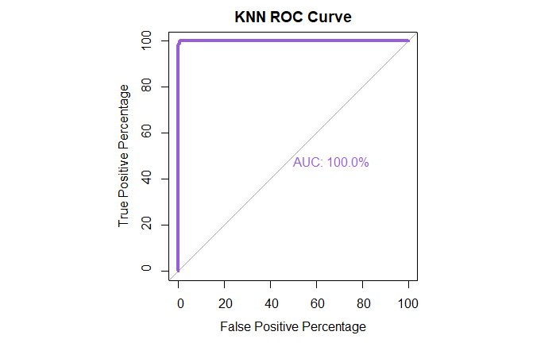

```r
knn.prob <- predict(knn.fit, newdata=blueTarpTrain, type = "prob") #returns df with col 0 (prob not blue tarp) and 1 (prob blue tarp)
par(pty="s")
knn_roc <- roc(blueTarpTrain$Blue_Tarp_or_Not, knn.prob[,2], plot=TRUE, legacy.axes=TRUE, percent=TRUE, xlab="False Positive Percentage", ylab="True Positive Percentage", col="#965fd4", lwd=4, print.auc=TRUE, main="KNN ROC Curve")
```

```r
roc.info_knn <- roc(blueTarpTrain$Blue_Tarp_or_Not, knn.prob[,2], legacy.axes=TRUE)
roc.knn.df <- data.frame(tpp=roc.info_knn$sensitivities*100, fpp=(1-roc.info_knn$specificities)*100, thresholds=roc.info_knn$thresholds)
#roc.knn.df[roc.knn.df>99 & roc.knn.df < 100,]
roc.knn.df
```

| tpp | fpp | thresholds |
| --- | --- | --- |
| 100.00000 | 100.00000000 | -Inf |
| 100.00000 | 0.82487698 | 0.03740157 |
| 100.00000 | 0.82283521 | 0.07495098 |
| 98.82571 | 0.34505993 | 0.07691949 |
| 98.76391 | 0.34505993 | 0.11079865 |
| 98.76391 | 0.34301815 | 0.15476190 |
| 98.76391 | 0.33280928 | 0.18333333 |
| 98.33127 | 0.19805215 | 0.26666667 |
| 98.20766 | 0.19805215 | 0.36666667 |
| 96.97157 | 0.12046471 | 0.45000000 |

[output cut: 8 more lines]

```r
knn.pred_50 <- ifelse(knn.prob[,2]>0.5,1,0)
cm.knn_50 <- confusionMatrix(factor(knn.pred_50), factor(blueTarpTrain$Blue_Tarp_or_Not), positive = '1')
"Threshold: 0.5"
```

```
[1] "Threshold: 0.5"
```

```r
cm.knn_50
```

```
Confusion Matrix and Statistics

          Reference
Prediction     0     1
         0 48920    50
         1    57  1568

               Accuracy : 0.9979
                 95% CI : (0.9974, 0.9983)
    No Information Rate : 0.968
    P-Value [Acc > NIR] : <2e-16

                  Kappa : 0.9659

 Mcnemar's Test P-Value : 0.5619

            Sensitivity : 0.96910
            Specificity : 0.99884
         Pos Pred Value : 0.96492
         Neg Pred Value : 0.99898
             Prevalence : 0.03198
         Detection Rate : 0.03099
   Detection Prevalence : 0.03212
      Balanced Accuracy : 0.98397

       'Positive' Class : 1
```

```r
knn.pred_077 <- ifelse(knn.prob[,2]>0.077,1,0)
cm.knn_077 <- confusionMatrix(factor(knn.pred_077), factor(blueTarpTrain$Blue_Tarp_or_Not), positive = '1')
"Threshold: 0.077"
```

```
[1] "Threshold: 0.077"
```

```r
cm.knn_077
```

```
Confusion Matrix and Statistics

          Reference
Prediction     0     1
         0 48808    19
         1   169  1599

               Accuracy : 0.9963
                 95% CI : (0.9957, 0.9968)
    No Information Rate : 0.968
    P-Value [Acc > NIR] : < 2.2e-16

                  Kappa : 0.9426

 Mcnemar's Test P-Value : < 2.2e-16

            Sensitivity : 0.98826
            Specificity : 0.99655
         Pos Pred Value : 0.90441
         Neg Pred Value : 0.99961
             Prevalence : 0.03198
         Detection Rate : 0.03160
   Detection Prevalence : 0.03494
      Balanced Accuracy : 0.99240

       'Positive' Class : 1
```

## Final Hold Out Performance

GLM

```r
glm.prob_FHO <- predict(glm.fit, newdata=blueTarpTest, type = "prob") #returns df with col 0 (prob not blue tarp) and 1 (prob blue tarp)
glm.pred_FHO <- ifelse(glm.prob_FHO[,2]>0.15,1,0)
cm.glm_50_FHO <- confusionMatrix(factor(glm.pred_FHO), factor(blueTarpTest$Blue_Tarp_or_Not), positive = '1')
cm.glm_50_FHO
```

```
Confusion Matrix and Statistics

          Reference
Prediction     0     1
         0 12163    15
         1    79   389

               Accuracy : 0.9926
                 95% CI : (0.9909, 0.994)
    No Information Rate : 0.9681
    P-Value [Acc > NIR] : < 2.2e-16

                  Kappa : 0.8884

 Mcnemar's Test P-Value : 8.142e-11

            Sensitivity : 0.96287
            Specificity : 0.99355
         Pos Pred Value : 0.83120
         Neg Pred Value : 0.99877
             Prevalence : 0.03195
         Detection Rate : 0.03076
   Detection Prevalence : 0.03701
      Balanced Accuracy : 0.97821

       'Positive' Class : 1
```

LDA

```r
lda.prob_FHO <- predict(lda.fit, newdata =blueTarpTest, type = "prob")
lda.pred_FHO <- ifelse(lda.prob_FHO[,2]> 0.10,1,0)
cm.lda_FHO <- confusionMatrix(factor(lda.pred_FHO), factor(blueTarpTest$Blue_Tarp_or_Not), positive="1")
cm.lda_FHO
```

```
Confusion Matrix and Statistics

          Reference
Prediction     0     1
         0 12097    62
         1   145   342

               Accuracy : 0.9836
                 95% CI : (0.9813, 0.9858)
    No Information Rate : 0.9681
    P-Value [Acc > NIR] : < 2.2e-16

                  Kappa : 0.7593

 Mcnemar's Test P-Value : 1.202e-08

            Sensitivity : 0.84653
            Specificity : 0.98816
         Pos Pred Value : 0.70226
         Neg Pred Value : 0.99490
             Prevalence : 0.03195
         Detection Rate : 0.02704
   Detection Prevalence : 0.03851
      Balanced Accuracy : 0.91735

       'Positive' Class : 1
```

QDA

```r
qda.prob_FHO <- predict(qda.fit, newdata =blueTarpTest, type = "prob")
qda.pred_FHO <- ifelse(qda.prob_FHO[,2]>0.10,1,0)
cm.qda_FHO <- confusionMatrix(factor(qda.pred_FHO), factor(blueTarpTest$Blue_Tarp_or_Not), positive="1")
cm.qda_FHO
```

```
Confusion Matrix and Statistics

          Reference
Prediction     0     1
         0 12138    39
         1   104   365

               Accuracy : 0.9887
                 95% CI : (0.9867, 0.9905)
    No Information Rate : 0.9681
    P-Value [Acc > NIR] : < 2.2e-16

                  Kappa : 0.8304

 Mcnemar's Test P-Value : 8.701e-08

            Sensitivity : 0.90347
            Specificity : 0.99150
         Pos Pred Value : 0.77825
         Neg Pred Value : 0.99680
             Prevalence : 0.03195
         Detection Rate : 0.02886
   Detection Prevalence : 0.03709
      Balanced Accuracy : 0.94749

       'Positive' Class : 1
```

KNN

```r
knn.prob_FHO <- predict(knn.fit, newdata =blueTarpTest, type = "prob")
knn.pred_FHO <- ifelse(knn.prob_FHO[,2]>0.077,1,0)
cm.knn_FHO <- confusionMatrix(factor(knn.pred_FHO), factor(blueTarpTest$Blue_Tarp_or_Not), positive="1")
cm.knn_FHO
```

```
Confusion Matrix and Statistics

          Reference
Prediction     0     1
         0 12197     4
         1    45   400

               Accuracy : 0.9961
                 95% CI : (0.9949, 0.9971)
    No Information Rate : 0.9681
    P-Value [Acc > NIR] : < 2.2e-16

                  Kappa : 0.9403

 Mcnemar's Test P-Value : 1.102e-08

            Sensitivity : 0.99010
            Specificity : 0.99632
         Pos Pred Value : 0.89888
         Neg Pred Value : 0.99967
             Prevalence : 0.03195
         Detection Rate : 0.03163
   Detection Prevalence : 0.03519
      Balanced Accuracy : 0.99321

       'Positive' Class : 1
```

## Results Table

[output not shown]

#### Threshold Justifications

Assuming that we have sufficient resources (personnel and the physical resources) to provide food and water for any blue tarps we find, our main priority is finding blue tarps and minimizing not finding blue tarps. The cost of human life is one that is impossible to truly quantify. The cost of potential resource waste due to false positives is worth the potential of saving a life. Due to the imbalanced nature of the data set we also need to keep in mind the proportion of false positives (FDR) compared to the proportion of TP. Therefore, we want predict as many TP as we can while keeping the precision high. It is alright to have some false positives but we don’t want them to be a large percentage of our predicted positives. However, we will prioritize keeping the FDR low due to the imbalance in the data set.

##### KNN

The KNN model performs well with 99.6% accuracy and 100% AUC. Based on the ROC graph, a threshold of 0.077 results in a sensitivity of 98.8% and 0.3% FPR. The FDR for this threshold is 9.6% the best of all the models. The KNN model with a 0.077 threshold achieves our objective of predicting a large TP% with a low FDR.

#### LDA

The LDA model, with a 98.2% accuracy and 98.9% AUC, does not perform as well as the KNN model. It was difficult to choose a threshold for this model and 0.10 was determined to have a reasonable trade off between FP and FN. A threshold of 0.10 results in a sensitivity of 84.7% and 1.3% FPR. The FDR for this threshold is 32.3%. This model does not perform as well as the KNN model and has and FDR that is too high.

#### Logistic Regression

The logistic regression model, with a 99.2% accuracy and 99.8% AUC, performs well. A threshold of 0.15 was selected which resulted in a sensitivity of 94.6% and 0.7% FPR. The FDR was 18.3%, which is still higher than would be preferred. This FDR is second best of the four models.

## Conclusions

Without a doubt, the KNN method performs the best with the highest accuracy, highest AUC, and highest precision (lowest FDR).The rest of the models, in order of best performance, are: Logistic Regression, QDA, and LDA. The final models when tested against the final hold out set performed well. Ordered from best to worst performing: KNN, logistic regression, QDA and LDA. These results support my previous conclusions.

Based on the previously outlined metrics, the KNN and logistic regression models are the two best of the four models created for this project. However, because time and accuracy are of the essence I would recommend that the logistic regression model be used. There will be more false positives classified by the logistic regression method compared to the KNN method. In our scenario, we have the personnel and resources to cover extra false positives. What we don’t have is extra time waiting for our classification system to return results of where to find the blue tarps.

I think the results of this project would be immensely successful in saving human lives. Any of these methods are much faster than a human scouring thousands of images looking for blue dots. These methods scale well and with the access to computing power that exists today any amount of data that were collected could be processed.

As a general strategy, I would recommend that each supply mission target areas that have the highest clusters of predicted blue tarps. That way if false positives are found the supply team can continue on to the next location and not have to spend as much time traveling from location to location.

To improve these results, RBG values could be converted into a singular color designation like a hexcode. Then an even better performing classification method like a Bayes decision boundary could be used to determine the line between colors that should be considered blue and indicate blue tarps and those that do not. Other ideas would be to add other forms of data that indicate variables other than color, like infrared or thermal imaging from satellites to detect people. People detected could then be cross referenced with areas where tarps might be located.

I think one thing that made it possible to use predictive models is that the object we were looking for really stood out in comparison to the environment that it was in. If the tarps had been brown or even red it would have been far more challenging to effectively classify it as a tarp and not some kind of vegetation or dirt. If the tarp had been a different color it’s possible these methods might not have worked at all and other data would have been needed to do any classification.

#### References

- Caret Documentation: https://topepo.github.io/caret/index.html
- ROCR Documentation: https://www.rdocumentation.org/packages/ROCR/versions/1.0-11
- My group’s STAT 6021 Final Project
- article about colorized ROC curves
- https://davidrroberts.wordpress.com/2015/09/22/quick-auc-function-in-r-with-rocr-package/
- https://www.youtube.com/watch?v=qcvAqAH60Yw&ab_channel=StatQuestwithJoshStarmer
- https://towardsdatascience.com/the-ultimate-guide-to-binary-classification-metrics-c25c3627dd0a#e16f
- https://towardsdatascience.com/demystifying-roc-curves-df809474529a
- https://mlr.mlr-org.com/articles/tutorial/roc_analysis.html
- https://towardsdatascience.com/understanding-auc-roc-curve-68b2303cc9c5